# TP 1 de MPA

# Question 1

$\underline {\text{Loi générative}}$

On a : $P(y|\theta)=\frac{P(y , \theta)}{\underbrace{P(\theta)}_{constante}} \propto P(y|\theta) \propto exp(\frac{-1}{32}(8y² - 4y\theta + \theta²)) \propto exp(\frac{-1}{32}(8y² - 4y\theta))$.

Donc, $P(y|\theta) \propto exp(\frac{-1}{32}(\sqrt8y - \frac{2}{\sqrt8}\theta)^2)$ (on a ajouté une constante pour faire apparaître l’identité remarquable).

D’où, $P(y|\theta) \propto exp(\frac{-1}{4}(y - \frac{1}{4}\theta)^2)$

On aperçoit l’expression d’une loi normale de paramètres $(\frac{\theta}{4},2)$.

Par identification on trouve $P(y|\theta)=\frac{1}{2\sqrt{\pi}} exp(\frac{-1}{4}(y - \frac{1}{4}\theta)^2)$.

Par conséquent, $\boxed{y|\theta \hookrightarrow \mathcal{N}\left(\frac{\theta}{4},2\right)}$ (respectivement les paramètres $m$ et $\sigma²$).

$\underline{\text{Loi à priori}}$

$P(\theta)=\frac{P(y,\theta)}{P(y|\theta)}=\frac{2\sqrt\pi}{16\pi} exp(\frac{-1}{32}(8y^2-4y\theta+\theta^2)+\frac{1}{4}(y-\frac{\theta}{4})^2)$

$P(\theta)=\frac{1}{8\sqrt{\pi}}exp(\frac{-\theta^2}{32}+\frac{\theta^2}{64})=\frac{1}{8\sqrt{\pi}}exp(\frac{-\theta^2}{64})$

D’où, $\boxed{\theta \hookrightarrow \mathcal{N}(0,32)}$.

## Question 2

$\underline {\text{Loi générative}}$

D’après la formule de Bayes on a

$$\begin{equation*}
\begin{split}
p(\theta \vert y) &= \dfrac{\text{p}(y \vert
\theta)\text{p}(\theta)}{\text{p}(y)} \\
& \propto \text{p}(y \vert \theta)\text{p}(\theta) \\
& \propto \operatorname{exp}\left(-\dfrac{1}{4}\left(y -
\dfrac{\theta}{4}\right)^2
\right)\operatorname{exp}\left(-\dfrac{\theta^2}{64} \right) \\
& \propto \operatorname{exp}\left( -\dfrac{1}{4}\left(y^2 -
\dfrac{y\theta}{2} + \dfrac{\theta^2}{16}\right) - \dfrac{\theta^2}{64}
\right) \\
& \propto \operatorname{exp}\left( -\dfrac{y^2}{4} +
\dfrac{y\theta}{8} - \dfrac{\theta^2}{64} - \dfrac{\theta^2}{64}\right)
\\
& \propto \operatorname{exp}\left(-\dfrac{\theta^2}{32} +
\dfrac{y\theta}{8}\right) \\
& \propto \operatorname{exp}\left(-\dfrac{1}{32} \left(\theta - 2y
\right)^2 \right) \hspace{1cm} \text{(Mise sous forme canonique)}
\end{split}
\end{equation*}$$

La loi de $\theta\vert y$ est proportionnelle à une loi normale de paramètre $\mathcal{N}(2y,16)$. Pour déterminer la constante $K$ réelle telle que p$(\theta\vert y) = K \operatorname{exp}\left(-\dfrac{1}{32} \left(\theta - 2y \right)^2 \right)$, on utilise la formule fournie dans l’énoncé, on sait que pour une loi normale de paramètre $\mathcal{N}(m,\sigma^2)$, la constante vaut $\dfrac{1}{\sqrt{2\pi\sigma^2}}$, ainsi $K = \dfrac{1}{\sqrt{32\pi}}$. Nous pouvons aussi utiliser la condition de normalisation suivante :

$$\int_{-\infty}^{+\infty}\text{p}(\theta\vert y)d\theta = 1$$

Et on a d’autre part :

$$\begin{equation*}
\begin{split}
\int_{-\infty}^{+\infty}\text{p}(\theta\vert y)d\theta & = K
\int_{-\infty}^{+\infty} \operatorname{exp}\left(-\dfrac{1}{32}
\left(\theta - 2y \right)^2 \right) d\theta\\
& \stackrel{u = \theta - 2y}{=} K \int_{-\infty}^{+\infty}
\operatorname{exp}\left(-\dfrac{1}{32} u^2 \right) du\\
& = K \sqrt{32\pi} \\
& = 1
\end{split}
\end{equation*}$$

On retrouve bien la même valeur de $K$. Par conséquent, $\boxed{\theta|y \hookrightarrow \mathcal{N}\left(2y,16\right)}$

$\underline{\text{Loi à priori}}$

$$\begin{equation*}
\begin{split}
p(y) &= \dfrac{\text{p}(y,\theta)}{\text{p}(\theta\vert y)} \\
&
= \dfrac{\dfrac{1}{16\pi}\operatorname{exp}\left(-\dfrac{1}{32}\left(8y^2
- 4y\theta + \theta^2 \right)\right)
}{\dfrac{1}{\sqrt{32\pi}}\operatorname{exp}\left(-\dfrac{1}{32}\left(\theta
- 2y\right)^2\right)} \\
& = \dfrac{4\sqrt{2}}{16\pi}\operatorname{exp}\left(-\dfrac{y^2}{4}
+ \dfrac{y\theta}{8} - \dfrac{\theta^2}{32} + \dfrac{\theta^2}{32} -
\dfrac{y\theta}{8} + \dfrac{y^2}{8}\right) \\
& =
\dfrac{1}{\sqrt{8\pi}}\operatorname{exp}\left(-\dfrac{y^2}{8}\right)
\end{split}
\end{equation*}$$

D’où, $\boxed{y\hookrightarrow \mathcal{N}(0,4)}$.

## Question 3

```r
# On génère des thetas à l'aide du résultat précédent
theta <- rnorm(1000,0,sqrt(32))
# On génère des y sachant les valeurs de theta
generative <- rnorm(1000,theta/4,sqrt(2))

# On assemble les résultats pour former des générations du couple (y, theta)
couple <- cbind(generative,theta)
```

## Question 4

On a :

$$\begin{equation*}
\begin{split}
E[\theta \vert y] & = \int_{-\infty}^{+\infty} \theta
\text{p}(\theta\vert y) d\theta \\
& = \dfrac{1}{\sqrt{32\pi}} \int_{-\infty}^{+\infty} \theta
\operatorname{exp}\left(-\dfrac{u^2}{32}\right) \\
& \stackrel{u = \theta - 2y}{=} \dfrac{1}{\sqrt{32\pi}}
\int_{-\infty}^{+\infty} (u+2y)
\operatorname{exp}\left(-\dfrac{u^2}{32}\right)du
\\
& = \dfrac{1}{\sqrt{32\pi}}
\left(\underbrace{\int_{-\infty}^{+\infty}
u\operatorname{exp}\left(-\dfrac{u^2}{32}\right)du}_{= 0 \text{ car
fonction impaire}} + \underbrace{\int_{-\infty}^{+\infty}
2y\operatorname{exp}\left(-\dfrac{u^2}{32}\right)du}_{= 2y
\sqrt{32\pi}} \right) \\
& = 2y
\end{split}
\end{equation*}$$

## Question 5

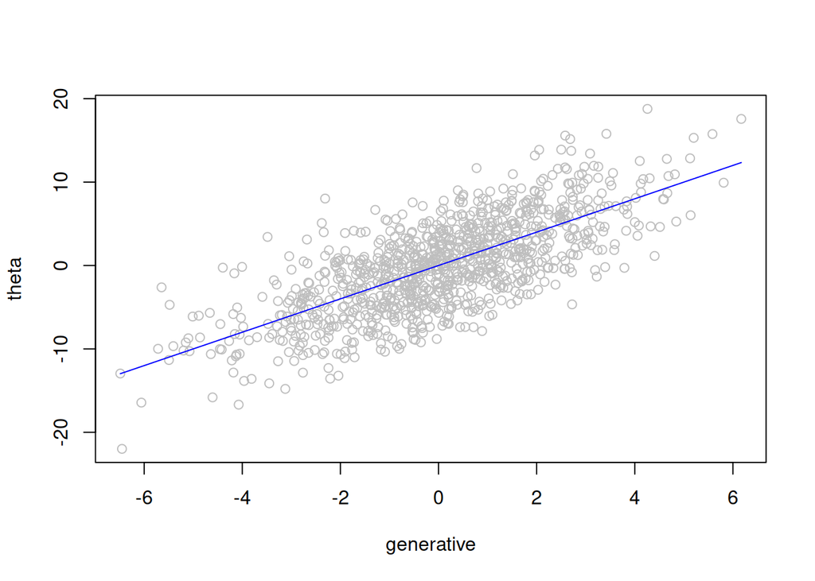

```r
theta <- rnorm(1000,0,sqrt(32))
generative <- rnorm(1000,theta/4,sqrt(2))

plot(generative,theta, col='grey')
lines(generative,2*generative, col='blue')
```

## Question 6

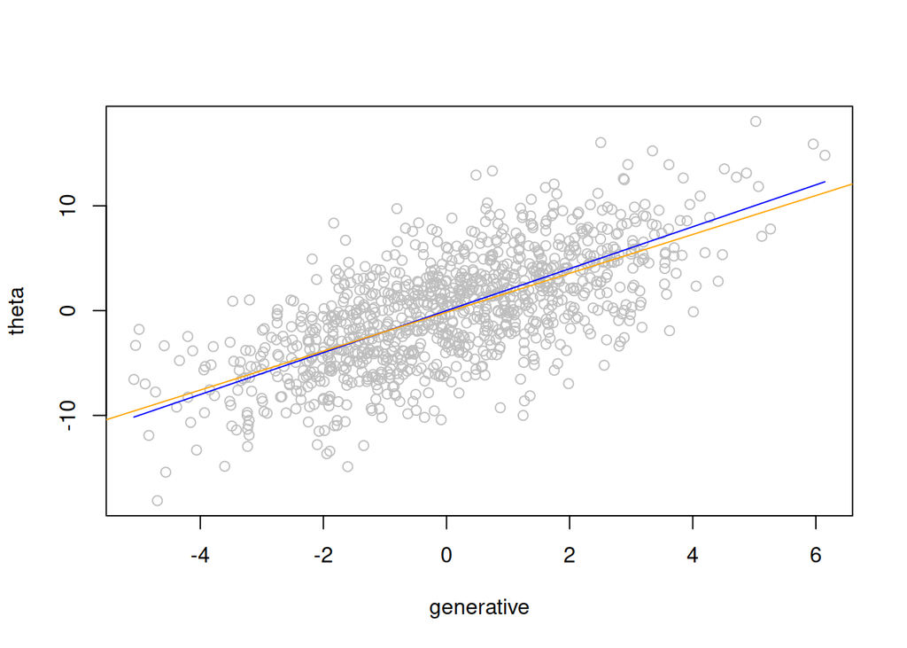

```r
theta <- rnorm(1000,0,sqrt(32))
generative <- rnorm(1000,theta/4,sqrt(2))

plot(generative,theta, col='grey')
lines(generative,2*generative, col='blue')

reg_lin <- lm(theta ~ generative)

abline(reg_lin, col='orange')
```

On constate une forte proximité entre les deux courbes. Le résultat théorique est à priori validé par les tirages aléatoires.

## Question 7

```r
theta_vector = c()

theta <- rnorm(100000,0, sqrt(32))
generative <- rnorm(100000,theta/4,sqrt(2))
theta_vector <- theta[generative > 1.99 & generative < 2.01]
```

## Question 8

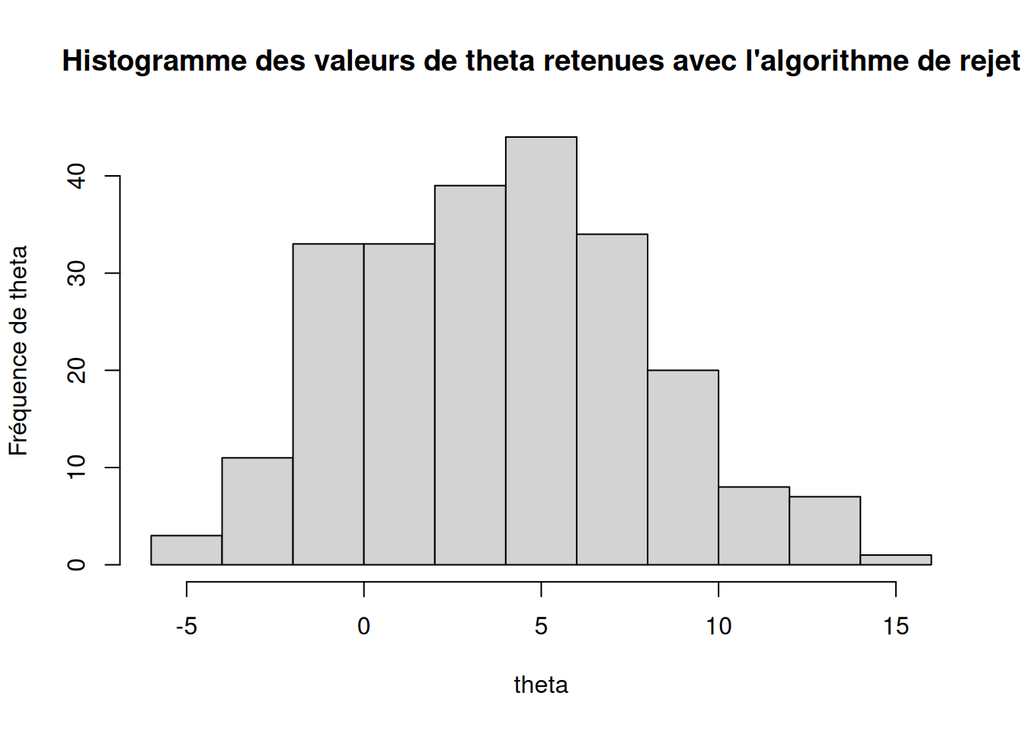

```r
hist(theta_vector, main = "Histogramme des valeurs de theta retenues avec l'algorithme de rejet",xlab ="theta", ylab = "Fréquence de theta")
```

L’histogramme montre que les valeurs de $\theta$ les plus fréquentes se situent aux environs de 4. Ceci s’explique par fait que y vaut approximativement 2 et car la loi à posteriori ($\theta$ | y) a une espérance de 2y.

## Question 9

La loi de vraissemblance fournit la donnée de $y$ en fonction du paramètre $\theta$. Tandis que la loi a posteriori fourni le comportement de $\theta$ après avoir observé $y$. Ainsi, toute l’information nécessaire sur la relation de $y$ et $\theta$ est dans $y|\theta$ et $\theta|y$.

## Question 10

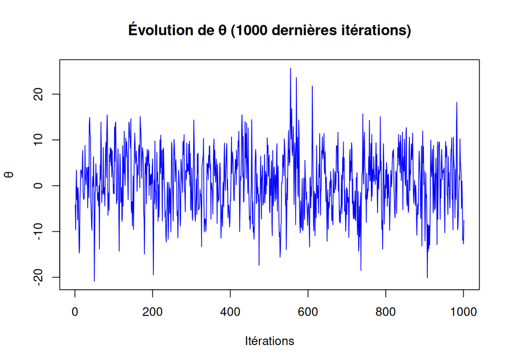

```r
n_total <- 2000
n_debut <- 1000

# Initialisation
theta_vecteur <- numeric(n_total)
y_vecteur <- numeric(n_total)
theta_vecteur[1] <- 0

# Échantillonnage de Gibbs
for (i in 2:n_total) {
    y_vecteur[i] <- rnorm(1, mean = theta_vecteur[i-1]/4, sd = 2)

    theta_vecteur[i] <- rnorm(1, mean = 2*y_vecteur[i], sd = 4)
}


# Tracé de θ (sans valeurs de début)
plot(theta_vecteur[n_debut:n_total], type="l", col="blue",
     main="Évolution de θ (1000 dernières itérations)",
     xlab="Itérations", ylab="θ")
```

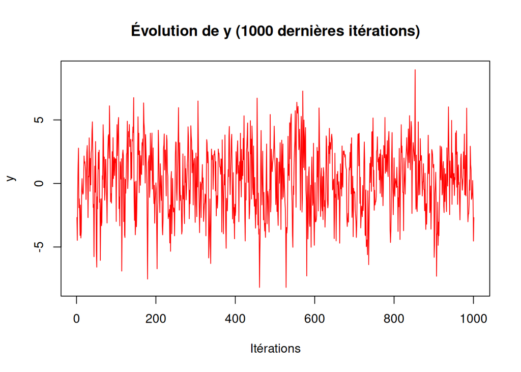

```r
# Tracé de y (sans valeurs de début)
plot(y_vecteur[n_debut:n_total], type="l", col="red",
     main="Évolution de y (1000 dernières itérations)",
     xlab="Itérations", ylab="y")
```

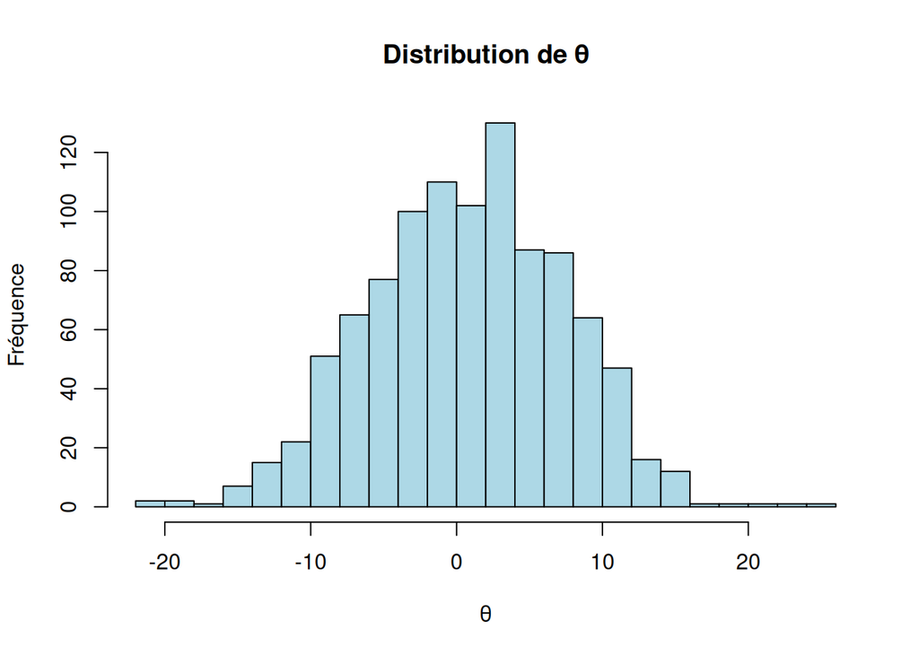

```r
# Histogramme de θ
hist(theta_vecteur[n_debut:n_total], breaks=30, col="lightblue",
     main="Distribution de θ", xlab="θ", ylab= "Fréquence")
```

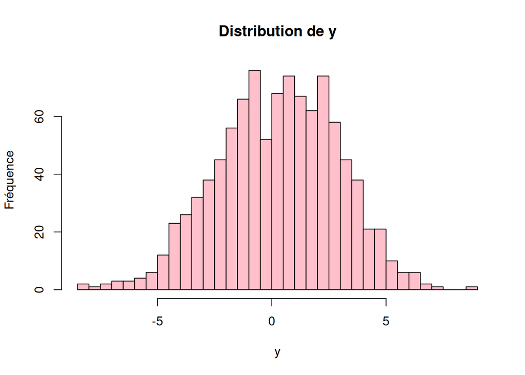

```r
# Histogramme de y
hist(y_vecteur[n_debut:n_total], breaks=30, col="pink",
     main="Distribution de y", xlab="y",ylab = "Fréquence")
```

```r
cat("Statistiques pour θ (toutes les valeurs):\n")
```

```
## Statistiques pour θ (toutes les valeurs):
```

```r
cat("Moyenne:", mean(theta_vecteur[0:n_total]), "\n")
```

```
## Moyenne: 0.4226329
```

```r
cat("Écart-type:", sd(theta_vecteur[0:n_total]), "\n")
```

```
## Écart-type: 6.56946
```

```r
cat("Statistiques pour θ (1000 dernières valeurs):\n")
```

```
## Statistiques pour θ (1000 dernières valeurs):
```

```r
cat("Moyenne:", mean(theta_vecteur[n_debut:n_total]), "\n")
```

```
## Moyenne: 0.7681127
```

```r
cat("Écart-type:", sd(theta_vecteur[n_debut:n_total]), "\n")
```

```
## Écart-type: 6.656643
```

```r
cat("\nStatistiques pour y (toutes les valeurs):\n")
```

```
##
## Statistiques pour y (toutes les valeurs):
```

```r
cat("Moyenne:", mean(y_vecteur[0:n_total]), "\n")
```

```
## Moyenne: 0.1415555
```

```r
cat("Écart-type:", sd(y_vecteur[0:n_total]), "\n")
```

```
## Écart-type: 2.611569
```

```r
cat("\nStatistiques pour y (1000 dernières valeurs):\n")
```

```
##
## Statistiques pour y (1000 dernières valeurs):
```

```r
cat("Moyenne:", mean(y_vecteur[n_debut:n_total]), "\n")
```

```
## Moyenne: 0.2809731
```

```r
cat("Écart-type:", sd(y_vecteur[n_debut:n_total]), "\n")
```

```
## Écart-type: 2.634566
```